# Penanganan Stasioneritas

Qaulan Sadiida Putri Sumarna

2025-10-01

# Library

```r
library(rio)
library(dplyr)
library(lubridate)
library(tseries)
```

```r
library(forecast)
library(ggplot2)
library(MASS)
```

# Import Data

```r
data_minyak <- import("https://raw.githubusercontent.com/Sadiida/mpdw/main/Pertemuan%202/Data/crude-oil-price.csv")

head(data_minyak)
```

```
##         date price percentChange change
## 1 1983-03-01 29.27            NA     NA
## 2 1983-04-01 30.63         4.646   1.36
## 3 1983-05-01 30.25        -1.241  -0.38
## 4 1983-06-01 31.38         3.736   1.13
## 5 1983-07-01 32.00         1.976   0.62
## 6 1983-08-01 31.59        -1.281  -0.41
```

```r
dt <- data_minyak[128:254, c(1, 2) ]
head(dt)
```

```
##           date price
## 128 1993-10-01 16.92
## 129 1993-11-01 15.43
## 130 1993-12-01 14.17
## 131 1994-01-01 15.19
## 132 1994-02-01 14.48
## 133 1994-03-01 14.79
```

```r
# Ubah data jadi time series bulanan
ts_minyak <- ts(dt$price, start = c(1993, 10), frequency = 12)
```

# Plot deret waktu

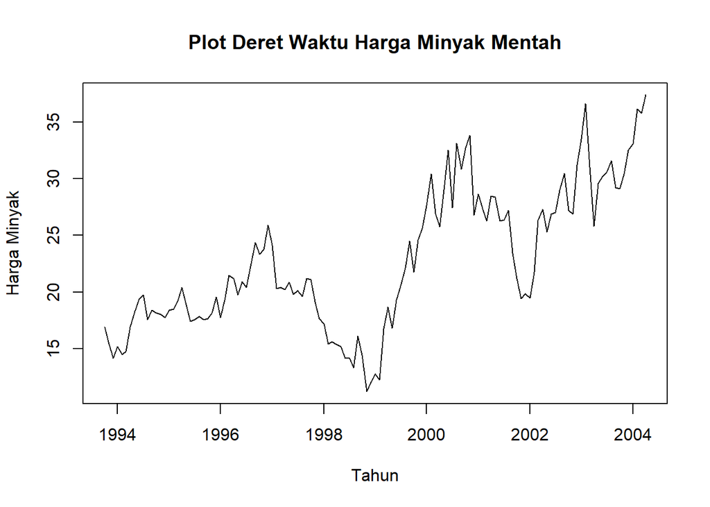

```r
plot(dt$date, dt$price, type = 'l',
     xlab = "Tahun", ylab = "Harga Minyak",
     main = "Plot Deret Waktu Harga Minyak Mentah")
```

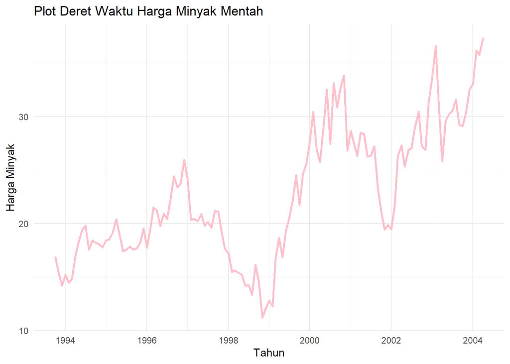

```r
# Plot deret waktu dengan ggplot2
ggplot(dt, aes(x = date, y = price)) +
  geom_line(color = "pink", linewidth = 1) +
  labs(
    title = "Plot Deret Waktu Harga Minyak Mentah",
    x = "Tahun",
    y = "Harga Minyak"
  ) +
  theme_minimal()
```

Jika dilihat dari plot deret waktu, data dapat dikatakan tidak stasioner baik dalam rataan dan ragam. Namun, untuk memastikan dilakukan uji yang lebih lanjut.

# Cek Stasionerits dalam Rataan

## Plot ACF

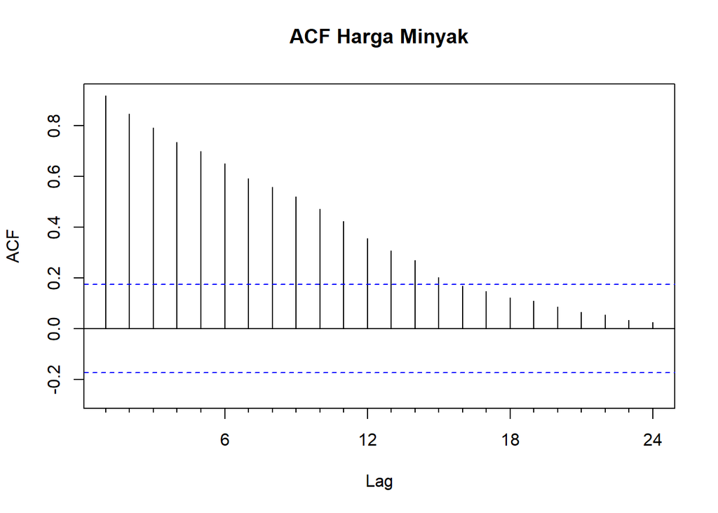

```r
Acf(ts_minyak, main = "ACF Harga Minyak")
```

## Uji ADF

$H_0$ : Data tidak stasioner dalam rataan

$H_1$ : Data stasioner dalam rataan

```r
tseries::adf.test(ts_minyak)
```

```
##
##  Augmented Dickey-Fuller Test
##
## data:  ts_minyak
## Dickey-Fuller = -2.0789, Lag order = 5, p-value = 0.5437
## alternative hypothesis: stationary
```

# Cek stasioneritas dalam Ragam

## Box-Cox

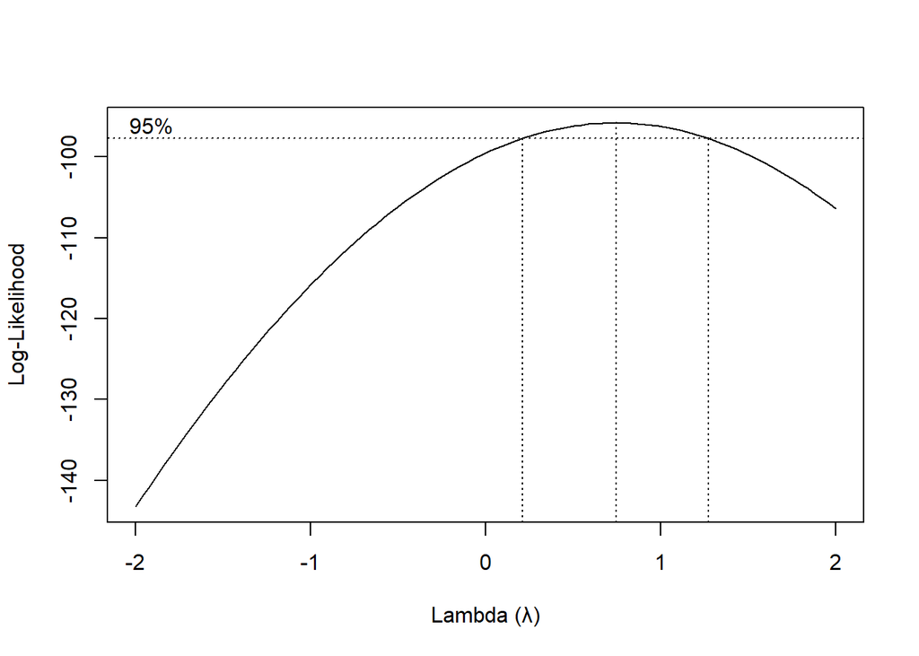

```r
bc <- boxcox(ts_minyak ~ time(ts_minyak),
       main = "Plot Diagnostik Box-Cox",
       xlab = "Lambda (λ)",
       ylab = "Log-Likelihood"
)
```

```r
# Nilai lambda optimum
lambda <- bc$x[which.max(bc$y)]
lambda
```

```
## [1] 0.7474747
```

Jika nilai lambda jauh dari 1, ini adalah indikasi kuat bahwa ragam data tidak stasioner dan perlu ditransformasi. Namun, lamda optimum menunjukkan angka yang dekat dengan angka 1 yaitu, 0.748. Sehingga untuk memastikan ulang, dicek selang kepercayaan untuk lamda.

```r
# Selang kepercayaan 95% untuk lambda
ci_lambda <- bc$x[bc$y > max(bc$y) - 0.5 * qchisq(0.95, 1)]

# Batas bawah dan batas atas
ci_lower <- min(ci_lambda)
ci_upper <- max(ci_lambda)

c(Batas_Bawah = ci_lower, Batas_Atas = ci_upper)
```

```
## Batas_Bawah  Batas_Atas
##   0.2222222   1.2323232
```

Karena selang kepercayaan 95% (0.222 – 1.232) memuat nilai 1, maka tidak ada cukup bukti statistik untuk menyatakan bahwa ragam data tidak stasioner. Oleh karena itu, transformasi Box-Cox tidak diperlukan.

# Kesimpulan

Sehingga didapat bahwa, data tidak stasioner dalam rataan namun stasioner dalam ragam. Sehingga perlu penanganan untuk ketidakstasioneran rataan.

# Penanganan: Differencing

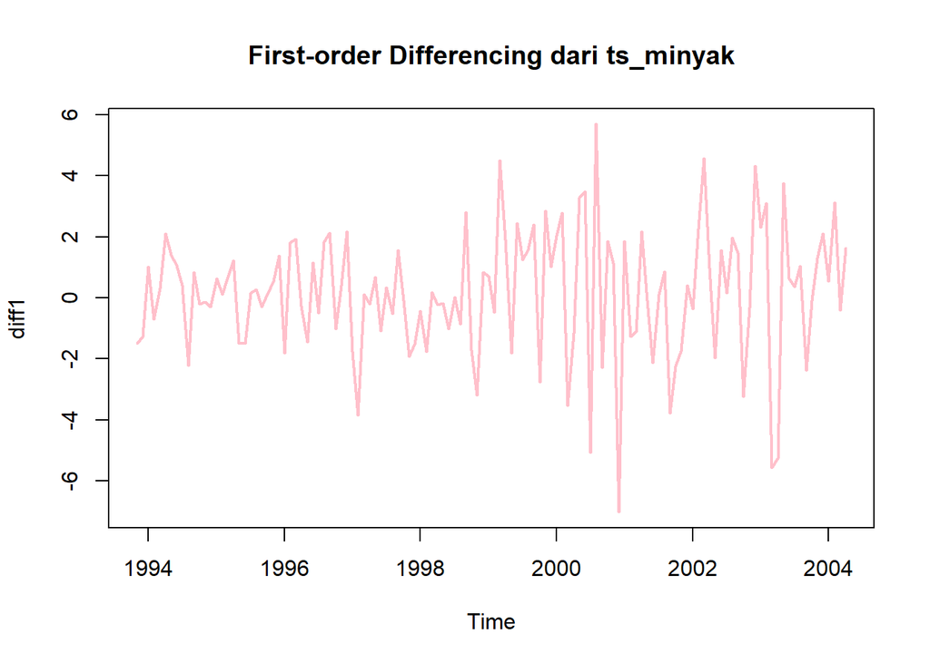

```r
# Differencing pertama pada postrend
diff1 <- diff(ts_minyak, differences = 1)

# Plot hasil differencing
ts.plot(diff1,
        main = "First-order Differencing dari ts_minyak",
        col = "pink", lwd = 2)
```

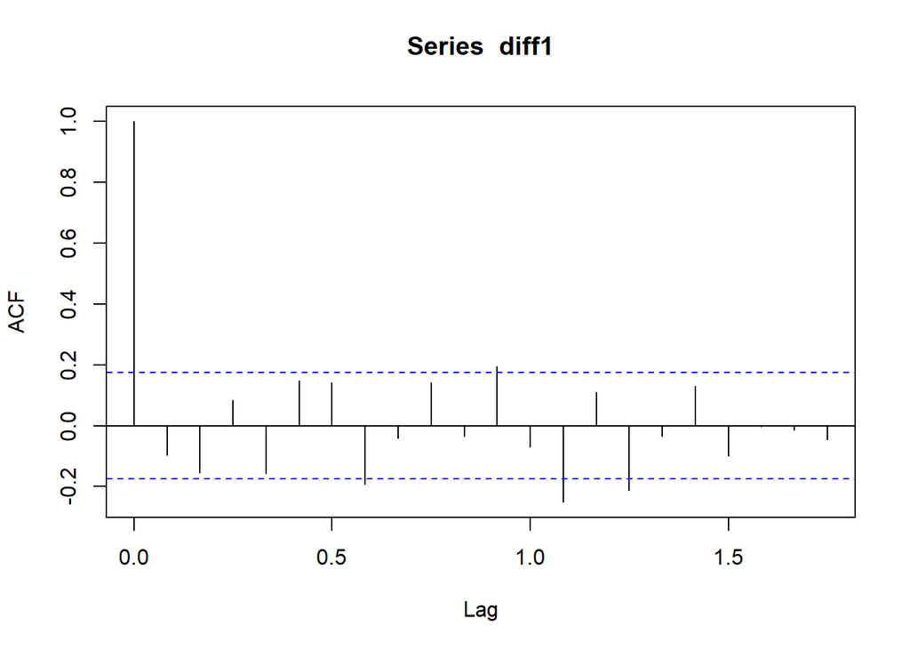

```r
acf(diff1)
```

### Uji ADF

```r
adf.test(diff1)
```

```
##
##  Augmented Dickey-Fuller Test
##
## data:  diff1
## Dickey-Fuller = -4.8591, Lag order = 4, p-value = 0.01
## alternative hypothesis: stationary
```

Berdasarkan uji ADF tersebut, didapat p-value sebesar 0.01 yang lebih kecil dari taraf nyata 5% sehingga tolak dan menandakan bahwa data sudah stasioner dalam rataan. Hal ini sesuai dengan hasil eksplorasi menggunakan plot time series dan plot ACF.